# Case Study: Welcome to University

datING - BDA 503 - Fall 2017

In this case study our group are going to explore university entrance examinations (YGS/LYS) data from 2017.

**Requested:**

MEF University management asks you to examine the data and provide insights that are useful to understand MEF University’s place among its competitors and in the undergraduate market. Our technical team cleaned up the data for you as best as they can (you can check the raw data from here). Data is provided with the following commands and necessary information can be found below. You should explicitly state your code and process with clear communication. Assume management knows a bit of R and would like to reproduce your work in case there is any problem with the calculations. The university is not interested in universities abroad (IDs that start with 3 or 4).

**Data load**

```r
# Download from GitHub (do it only once)
download.file("https://mef-bda503.github.io/files/osym_data_2017.RData",
               "osym_data_2017.RData")

#Install tidyverse if not already installed
 if (!("tidyverse" %in% installed.packages())) {
   install.packages("tidyverse", repos = "https://cran.pau.edu.tr")
 }
# Load tidyverse package
library(tidyverse)
# Load the data
load("osym_data_2017.RData")
```

```r
# Nature of rows and columns/quick review of dataset
library(dplyr)
options(dplyr.width=Inf)

library(readr)
glimpse(osym_data_2017)
```

```
## Observations: 11,031
## Variables: 14
## $ program_id        <int> 100110266, 100110487, 100110724, 100130252, ...
## $ university_name   <chr> "ABANT İZZET BAYSAL ÜNİVERSİTESİ", "ABANT İZ...
## $ city              <chr> "BOLU", "BOLU", "BOLU", "BOLU", "BOLU", "BOL...
## $ faculty_name      <chr> "Bolu Sağlık Yüksekokulu", "Bolu Turizm İşle...
## $ program_name      <chr> "Hemşirelik", "Gastronomi ve Mutfak Sanatlar...
## $ exam_type         <chr> "YGS_2", "YGS_4", "YGS_6", "YGS_6", "MF_3", ...
## $ general_quota     <int> 150, 60, 60, 60, 80, 1, 40, 60, 60, 80, 60, ...
## $ general_placement <int> 150, 60, 62, 26, 80, 1, 9, 62, 60, 81, 60, 7...
## $ min_score         <dbl> 328.8790, 346.4491, 225.7170, 199.2710, 446....
## $ max_score         <dbl> 376.3817, 388.3141, 290.2683, 234.9510, 451....
## $ val_quota         <dbl> 4, 2, 2, 2, 2, 0, 1, 2, 2, 2, 2, 2, 2, 3, 2,...
## $ val_placement     <dbl> 4, 2, 0, 0, 2, 0, 0, 0, 2, 1, 2, 2, 2, 3, 1,...
## $ val_min_score     <dbl> 312.8462, 293.6994, 180.0000, 180.0000, 437....
## $ val_max_score     <dbl> 328.0626, 328.7560, 180.0000, 180.0000, 442....
```

### **Analysis of OSYM 2017 Data**

We filtered abroad universities that university management is not interested(IDs that start with 3 or 4)

```r
#Filtered abroad university
except_abroad <- osym_data_2017 %>% filter(program_id<300000000)
```

We compared averaged min scores.

```r
#Comparing Engineering Faculties avarage of Min Scores of each program between MEF & The Other Universities s

mef_uni <- except_abroad %>% filter(university_name == "MEF ÜNİVERSİTESİ")

mef_uni_muh <- mef_uni %>% filter(faculty_name == "Mühendislik Fakültesi")

min(mef_uni_muh$min_score)
```

```
## [1] 251.2545
```

```r
max(mef_uni_muh$min_score)
```

```
## [1] 429.7522
```

```r
other_uni_muh <-  except_abroad %>% filter(faculty_name == "Mühendislik Fakültesi")

mean(mef_uni_muh$min_score)
```

```
## [1] 349.4905
```

```r
mean(other_uni_muh$min_score)
```

```
## [1] 306.0246
```

### **Assignments of data**

```r
#Distinct faculties of all univerties
faculties <- except_abroad %>% distinct(university_name, faculty_name, .keep_all = TRUE)

#Distinct faculties of MEF univerties
mef_faculties <- mef_uni %>% distinct(university_name, faculty_name, .keep_all = TRUE)

#Mef total quota group by its faculties
mef_faculty_quota <- except_abroad %>%
  filter(university_name == "MEF ÜNIVERSITESI") %>%
  group_by(faculty_name) %>%
  summarise(count=n(), total_quota = sum(general_quota))

# Total quota of Engineering Faculty of MEF
mef_uni_muh_quota <- mef_uni_muh %>%
  summarise( count=n(), total_quota = sum(general_quota))

# All engineering faculties of univeresities in Istanbul
total_uni_muh_ist <-  other_uni_muh %>% filter(city == "İSTANBUL")

#Average quota of Engineering Faculty of the other universites in Istanbul
other_ist_muh_quota <- total_uni_muh_ist %>%
  summarise( count=n(), total_quota = mean(general_quota))
```

### **Data Visualization**

This data shows quota of universities in Istanbul

```r
# Quota of Engineering Faculty of the each universites in Istanbul
total_eng_faculty_quota <- except_abroad %>%
  filter(city == "İSTANBUL" & faculty_name == "Mühendislik Fakültesi") %>%
  group_by(university_name, faculty_name) %>%
  summarise(count_of_program_name=n(), total_quota = sum(general_quota))
```

Visualize data in bar chart.

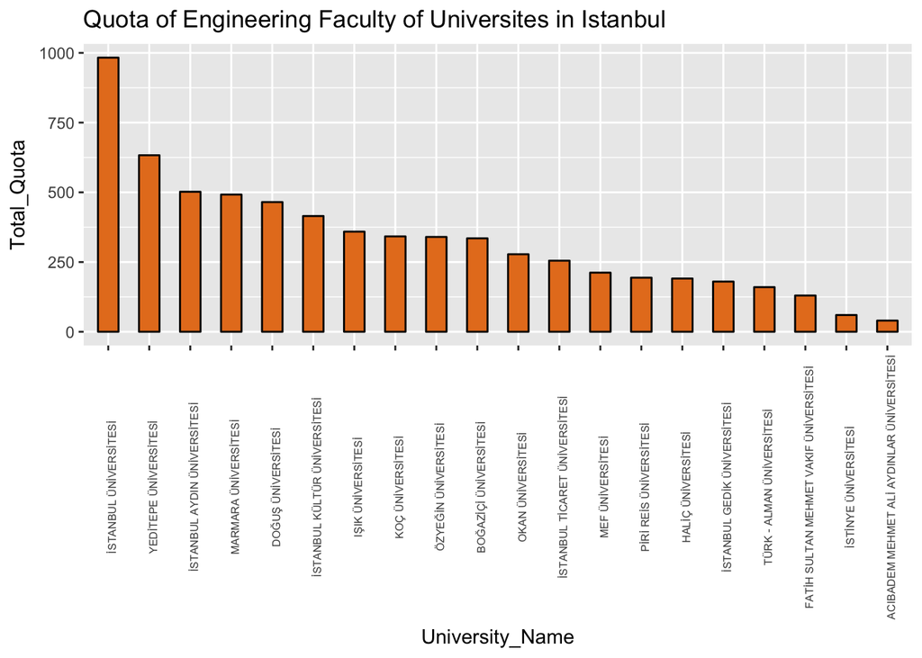

```r
library(ggplot2)

ggplot(data=total_eng_faculty_quota, aes(x=reorder(university_name,-total_quota),y=total_quota, fill=time)) +
  geom_bar(colour="black", fill="#e67e22", width=.5, stat="identity",aes(fill=university_name=='MEF ÜNİVERSİTESİ')) +
  guides(fill=FALSE) +
  xlab("University_Name") + ylab("Total_Quota") +
  ggtitle("Quota of Engineering Faculty of Universites in Istanbul")+
  theme(axis.text.x = element_text(angle=90, size=6))
```